# Kim, Capotosto, Hartry & Fitzgerald (2011) Analysis and Replication

Anwesha Guha, Merly Klaas, Thuy Nguyen

2/8/2022

**A. Baseline randomization checks**

**A1.** Create a table comparing the baseline characteristics (family income, gender, test score) for students assigned to the treatment and control conditions. Assess and describe whether the randomization process generated identical treatment and control conditions. Describe the results of your assessment in 1-2 sentences. If it did not (or if it had not), would this invalidate the causal claims of the study? Why or why not?

```
##
##
## |                            |    0 (N=157)     |    1 (N=155)     |  Total (N=312)   | p value|
## |:---------------------------|:----------------:|:----------------:|:----------------:|-------:|
## |**frpl**                    |                  |                  |                  |   0.493|
## |&nbsp;&nbsp;&nbsp;Mean (SD) |  0.707 (0.457)   |  0.671 (0.471)   |  0.689 (0.464)   |        |
## |&nbsp;&nbsp;&nbsp;Range     |  0.000 - 1.000   |  0.000 - 1.000   |  0.000 - 1.000   |        |
## |**female**                  |                  |                  |                  |   0.503|
## |&nbsp;&nbsp;&nbsp;Mean (SD) |  0.561 (0.498)   |  0.523 (0.501)   |  0.542 (0.499)   |        |
## |&nbsp;&nbsp;&nbsp;Range     |  0.000 - 1.000   |  0.000 - 1.000   |  0.000 - 1.000   |        |
## |**dorf**                    |                  |                  |                  |   0.783|
## |&nbsp;&nbsp;&nbsp;Mean (SD) | 86.245 (25.936)  | 87.121 (30.117)  | 86.680 (28.049)  |        |
## |&nbsp;&nbsp;&nbsp;Range     | 18.791 - 153.762 | 15.315 - 165.104 | 15.315 - 165.104 |        |
```

```
##
##
## Table: Descriptive statistics by assigned treatment
##
## |                             |   0 (N=157)   |   1 (N=155)   | Total (N=312) | p value|
## |:----------------------------|:-------------:|:-------------:|:-------------:|-------:|
## |**Free/Reduced Price Lunch** |               |               |               |   0.493|
## |&nbsp;&nbsp;&nbsp;Mean (SD)  |  0.71 (0.46)  |  0.67 (0.47)  |  0.69 (0.46)  |        |
## |**Prop. Female**             |               |               |               |   0.503|
## |&nbsp;&nbsp;&nbsp;Mean (SD)  |  0.56 (0.50)  |  0.52 (0.50)  |  0.54 (0.50)  |        |
## |**Baseline DIBELS**          |               |               |               |   0.783|
## |&nbsp;&nbsp;&nbsp;Mean (SD)  | 86.24 (25.94) | 87.12 (30.12) | 86.68 (28.05) |        |
```

While data is not large, can still use an omnibus F test for balance:

```
##
## Call:
## lm(formula = treat ~ frpl + female + dorf, data = dare3)
##
## Residuals:
##     Min      1Q  Median      3Q     Max
## -0.5511 -0.5025 -0.4587  0.4965  0.5422
##
## Coefficients:
##               Estimate Std. Error t value Pr(>|t|)
## (Intercept)  0.5338301  0.1143816   4.667 4.56e-06 ***
## frpl        -0.0407333  0.0619871  -0.657    0.512
## female      -0.0372214  0.0573499  -0.649    0.517
## dorf         0.0001292  0.0010291   0.126    0.900
## ---
## Signif. codes:  0 '***' 0.001 '**' 0.01 '*' 0.05 '.' 0.1 ' ' 1
##
## Residual standard error: 0.5025 on 308 degrees of freedom
## Multiple R-squared:  0.002993,   Adjusted R-squared:  -0.006718
## F-statistic: 0.3082 on 3 and 308 DF,  p-value: 0.8195
```

**B. Replication and Extension**

**B1.** Estimate the bivariate relationship between students’ final reading comprehension outcomes and their attendance rate (proportion of days attended) in a seven-month READ180 program. Present these results in a table with an accompanying discussion of what these results show and whether they should be understood as the causal effect of READ180 on reading comprehension outcomes in 1 paragraph.

```
##
## Call:
## lm(formula = sat10_compreh ~ read180_attend + dorf + female +
##     frpl, data = dare3)
##
## Residuals:
##     Min      1Q  Median      3Q     Max
## -67.068  -8.951  -0.153   9.995  63.620
##
## Coefficients:
##                 Estimate Std. Error t value Pr(>|t|)
## (Intercept)    542.25887    3.99719 135.660  < 2e-16 ***
## read180_attend   9.66249    2.26095   4.274 2.57e-05 ***
## dorf             0.98438    0.03489  28.215  < 2e-16 ***
## female           1.18273    1.94452   0.608   0.5435
## frpl            -4.30718    2.10567  -2.046   0.0417 *
## ---
## Signif. codes:  0 '***' 0.001 '**' 0.01 '*' 0.05 '.' 0.1 ' ' 1
##
## Residual standard error: 17.03 on 307 degrees of freedom
## Multiple R-squared:  0.7364, Adjusted R-squared:  0.733
## F-statistic: 214.4 on 4 and 307 DF,  p-value: < 2.2e-16
```

```
##
## <table style="text-align:center"><tr><td colspan="2" style="border-bottom: 1px solid black"></td></tr><tr><td style="text-align:left">read180_attend</td><td>11.111<sup>*</sup></td></tr>
## <tr><td style="text-align:left"></td><td>(4.326)</td></tr>
## <tr><td style="text-align:left"></td><td></td></tr>
## <tr><td colspan="2" style="border-bottom: 1px solid black"></td></tr><tr><td style="text-align:left">Observations</td><td>312</td></tr>
## <tr><td style="text-align:left">R<sup>2</sup></td><td>0.021</td></tr>
## <tr><td colspan="2" style="border-bottom: 1px solid black"></td></tr><tr><td style="text-align:left"><em>Note:</em></td><td style="text-align:left"><sup>*</sup>p<0.05; <sup>**</sup>p<0.01; <sup>***</sup>p<0.001</td></tr>
## </table>
```

It is likely to have endogenous differences in the expected outcomes between children who attended after-school program at a high rate and those attended at a lower rate. The OLS estimate of the predictor read180_attend is likely to be correlated with the residuals in the outcome test score sat10_compreh.

**B2.** Compare the average post-test reading comprehension scores of students who were assigned to participate in the READ180 intervention with those who were not. Present a figure comparing these mean differences. Is the difference in these scores meaningful and does the difference reflect anything other than sampling idiosyncrasy?

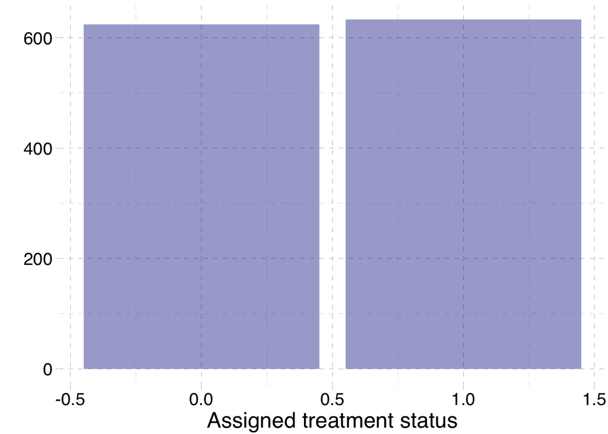

**B3.** Estimate Intent-to-Treat estimates of being assigned to participate in an after-school READ180 intervention. Present these results in a table and an accompanying write-up as you would report these in an academic paper in 1 paragraph. What differences are there in the results you estimated in response to this question and those for question B2?

First, visualize ITT effects.

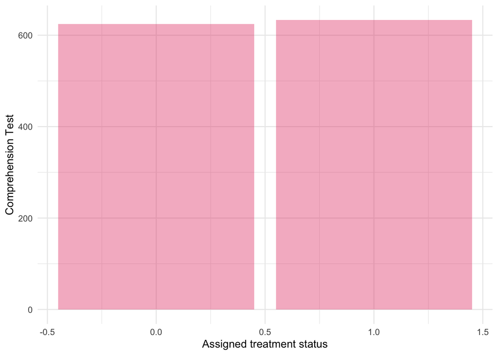

Then, estimate the models.

Table 1. Intent-to-Treat Estimates of READ180 on Test of Comprehension

|  | Model 1 | Model 2 | Model 3 |
| --- | --- | --- | --- |
| treat | 9.014* | 8.037*** | 8.003*** |
|  | (3.703) | (1.935) | (1.935) |
| frpl |  | −4.553* | −4.243* |
|  |  | (2.106) | (2.122) |
| female |  | 1.328 | 1.232 |
|  |  | (1.949) | (1.953) |
| School Fixed Effects | No | No | Yes |
| dorf |  | 0.985*** | 0.985*** |
|  |  | (0.035) | (0.035) |
| Num.Obs. | 312 | 312 | 312 |

**B4.** Identify the effects of full participation in a seven month after-school READ180 reading intervention. In other words: what are the effects of 100 percent attendance in a seven-month reading program, compared to not attending at all? Describe the model you estimate, its accompanying assumptions and defend the extent to which these assumptions are met in your analysis. Present these results in a table and an accompanying write-up as you would report these in an academic paper in 2-3 paragraphs.

```
## TSLS estimation, Dep. Var.: sat10_compreh, Endo.: read180_attend, Instr.: treat
## Second stage: Dep. Var.: sat10_compreh
## Observations: 312
## Standard-errors: IID
##                      Estimate Std. Error    t value   Pr(>|t|)
## (Intercept)        542.012827   4.019219 134.855273  < 2.2e-16 ***
## fit_read180_attend  10.235682   2.460318   4.160309 4.1302e-05 ***
## dorf                 0.984310   0.034892  28.209946  < 2.2e-16 ***
## frpl                -4.273159   2.106678  -2.028388 4.3384e-02 *
## female               1.191871   1.944788   0.612854 5.4043e-01
## ---
## Signif. codes:  0 '***' 0.001 '**' 0.01 '*' 0.05 '.' 0.1 ' ' 1
## RMSE: 16.9   Adj. R2: 0.732925
## F-test (1st stage), read180_attend: stat = 1,669.6     , p < 2.2e-16 , on 1 and 307 DoF.
##                         Wu-Hausman: stat =     0.348785, p = 0.555238, on 1 and 306 DoF.
```

Table 2. Instrumental variable estimates of attending READ 180 Intervention on Test Scores due to random assignment to after-school READ180 intervention

READ180 attendace

11.472*

10.236***

10.208***

10.208***

(4.708)

(2.460)

(2.464)

(0.788)

Prestest Score

0.984***

0.985***

0.985***

(0.035)

(0.035)

(0.049)

Eligible for free lunch

−4.273*

−3.992

−3.992

(2.107)

(2.121)

(4.061)

School FE

No

No

Yes

Yes

Female

1.192

1.114

1.114

(1.945)

(1.949)

(1.480)

Num.Obs.

312

312

312

312

* p < 0.05, ** p < 0.01, *** p < 0.001

In model 1, when we did not control for any covariate, we found a gain of 11 points for students who participated in READ 180 program, while after including students background characteristics such as eligibility for free lunch status, sex, and pre-test scores, we found 1.2 point less increase on reading score. The similiar estimation of 10.2 points increase was also found in model 3 and 4 when we accounted for school fixed effects and clustering standard errors at the level of randomization (within school).

Table 3. Comparison of OLS, ITT and IV estimates of Full Attendance of READ180 intervention on Post-test scores due to random offer to participate in READ180

OLS

ITT

TOT

TOT

TOT

READ180 attendace

9.662***

11.472*

10.236***

10.208***

(2.261)

(4.708)

(2.460)

(0.788)

Random Offer to READ180

8.037***

(1.935)

School FE

No

No

No

No

Yes

Student Chars.

Yes

Yes

No

Yes

Yes

Clust. SEs

No

No

No

No

Yes

Num.Obs.

312

312

312

312

312

* p < 0.05, ** p < 0.01, *** p < 0.001

**B5.** Write a discussion paragraph in which you present the substantive conclusions (and limitations) of your results about the effects of the after-school READ180 intervention you have documented.

The estimates of the endogenous relationship between attending READ 180 Enterprise Intervention program to improve the reading achievement of Low-Performing Elementary School Students (Model 1) imply that students reading achievement who attended Read 180 program are 9 points higher than those who are not. In Model 2, we present results of being randomly assigned to attend READ 180 instead of the traditional after-school program. We found that the offer of attending READ 180 program increased reading test scores about 8 points. Finally, Models 3-5 present a taxonomy of Treatment-on-the-Treated estimates in which we use the randomized assignment to READ 180 program as an instrument to estimate impact on attending READ 180 on students reading achivement. We found consistent effects of attending READ 180 Intervention on the increased reading achievement score for about 10 scaled score points. These models are robust to the inclusion of baseline student characteristics, school fixed effects, and the clustering of standard errors at the level of randomization (within school).